# PA1_template.Rmd

## Imputing missing values

### Calculate and report the total number of missing values in the dataset.

```r
sum(is.na(activitydf$steps))
```

```
## [1] 2304
```

### Devise a strategy for filling in all of the missing values in the dataset.

### Create a new dataset that is equal to the original dataset but with the missing data filled in.

```r
activitydfNA <- activitydf
activitydfNA[["steps"]][is.na(activitydfNA[["steps"]])] <- 0
DailyStepsCount <- aggregate(steps ~ date, subset(activitydfNA,!is.na(activitydf$steps)), sum)
```

### Make a histogram of the total number of steps taken each day and Calculate and report the mean and median total number of steps taken per day.

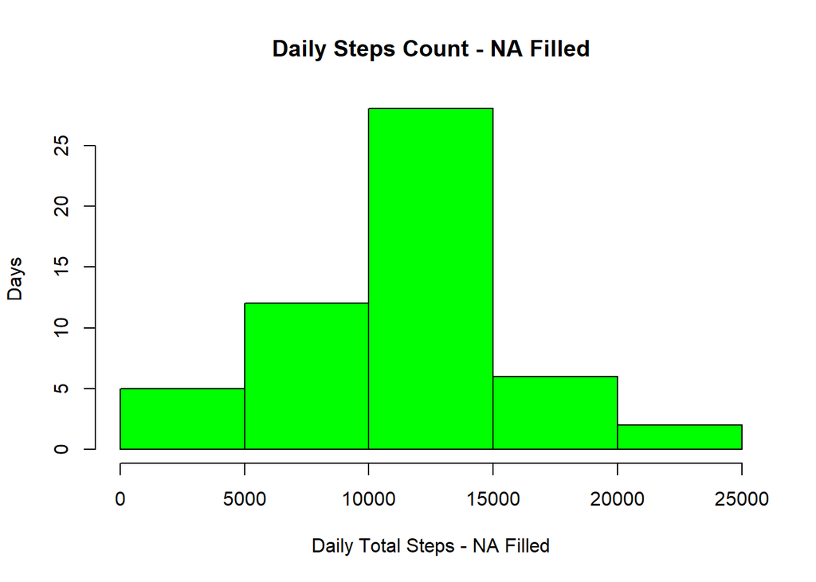

```r
hist(DailyStepsCount$steps,col="green",xlab="Daily Total Steps - NA Filled",ylab="Days",main="Daily Steps Count - NA Filled")
```

### Calculate and report the mean and median total number of steps taken per day.

```r
mean(DailyStepsCount$steps)
```

```
## [1] 10766.19
```

```r
median(DailyStepsCount$steps)
```

```
## [1] 10765
```

## Are there differences in activity patterns between weekdays and weekends?

### Create a new factor variable in the dataset with two levels - “weekday” and “weekend” indicating whether a given date is a weekday or weekend day.

```r
activitydfNA$date <- as.Date(strptime(activitydfNA$date, format="%Y-%m-%d"))

weekdaysdf <- transform(activitydfNA, wday = ifelse(weekdays(activitydfNA$date) =="Saturday" | weekdays(activitydfNA$date) =="Sunday" ,"weekend","weekday"))
```

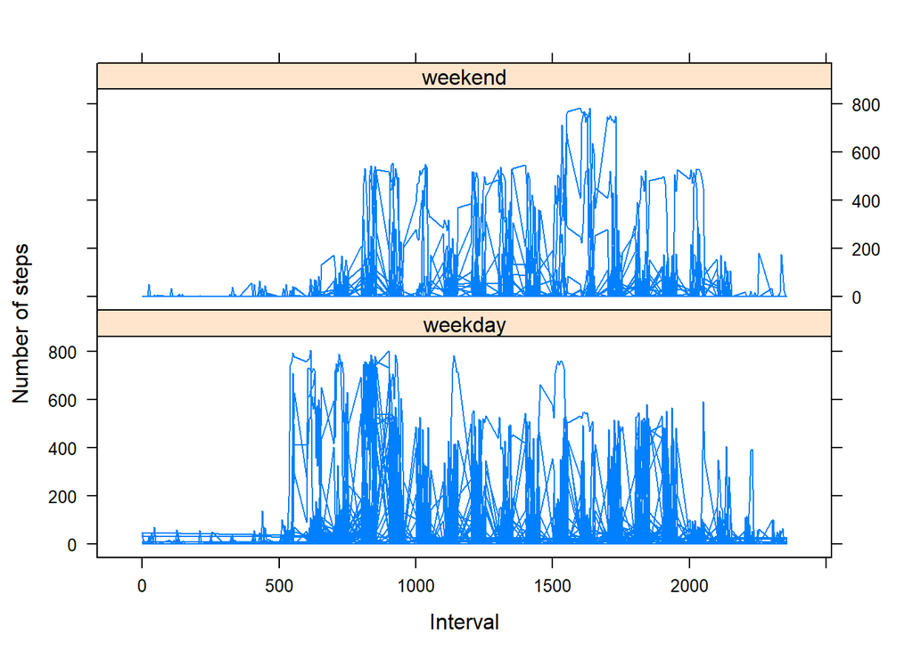

```r
library(lattice)

xyplot(steps ~ interval | wday, weekdaysdf, type = "l", layout = c(1, 2),xlab = "Interval", ylab = "Number of steps")
```